# R Notebook

What does our distribution look like???

How far apart are the values typically???

Is it a very narrow & tall distribution, or is it more wide & short???

Range

= max value - min value

```r
library(tidyverse)
library(janitor)
jobs <- read_csv("data/TyrellCorpJobs.csv") %>%
  select(-1) %>%
  clean_names()
```

```r
jobs %>%
  summarise(range = diff(range(salary)))
```

| range |
| --- |
| 61568 |

```r
jobs %>%
  summarise(range = range(salary))
```

| range |
| --- |
| 29459 |
| 91027 |

The range of our data is $61,568

> We MUST visualise our data

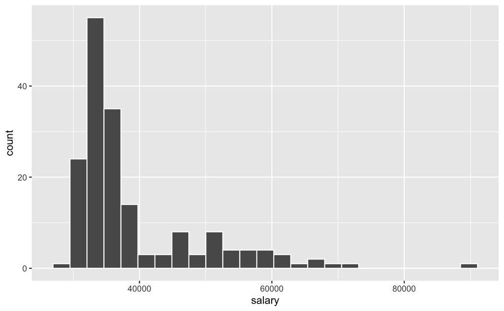

```r
jobs %>%
  ggplot(aes(x = salary)) +
  geom_histogram(col = "white", bins = 25)
```

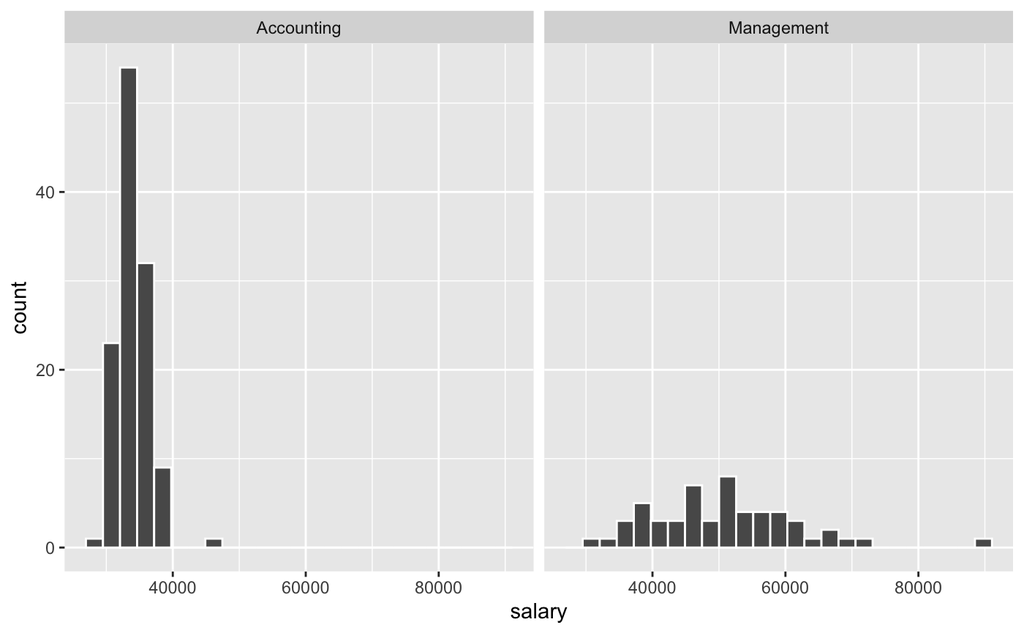

```r
jobs %>%
  ggplot(aes(x = salary)) +
  geom_histogram(col = "white", bins = 25) +
  facet_wrap(~ position)
```

There is strong evidence of **bimodality**

```r
jobs %>%
  group_by(position) %>%
  summarise(
    range = diff(range(salary))
  )
```

| position | range |
| --- | --- |
| Accounting | 15535 |
| Management | 59366 |

There is *more* salary disparity in management than in accounting

Range is also *heavily affected* by extreme values Most accounting salaries are between 30-40k - the range suggests a spreak of 15k ~50% more

Less influenced by outliers is the **INTERQUARTILE RANGE**

There are *3* quartiles which split the data into *4*

> 0 - 25 | *Q1* | 25 - 100 0 - 50 | *Q2* | 50 - 100 (median) 0 - 75 | *Q3* | 75 - 100

interquartile range = range of q1 to q3

```r
jobs %>%
  group_by(position) %>%
  summarise(
    q1 = quantile(salary, 0.25),
    q2 = quantile(salary, 0.5),
    q3 = quantile(salary, 0.75),
    iqr = q3 - q1,
    iqr_from_stats = IQR(salary)
  )
```

| position | q1 | q2 | q3 | iqr | iqr_from_stats |
| --- | --- | --- | --- | --- | --- |
| Accounting | 32390.5 | 34150 | 35265.0 | 2874.5 | 2874.5 |
| Management | 43698.0 | 50300 | 57288.5 | 13590.5 | 13590.5 |

The five figure summary

Min. :29459 —> min value 1st Qu.:33038 —> q1 Median :35009 —> q2 / median Mean :39383 —> mean 3rd Qu.:41990 —> q3 Max. :91027 —> max value

```r
summary(jobs)
```

```
   position             salary
 Length:175         Min.   :29459
 Class :character   1st Qu.:33038
 Mode  :character   Median :35009
                    Mean   :39383
                    3rd Qu.:41990
                    Max.   :91027
```

```r
library(skimr)
```

```r
jobs %>%
  group_by(position) %>%
  skim()
```

```
── Data Summary ────────────────────────
                           Values
Name                       Piped data
Number of rows             175
Number of columns          2
_______________________
Column type frequency:
  numeric                  1
________________________
Group variables            position
```

|  | skim_variable | position | n_missing | complete_rate | mean | sd | p0 | p25 | p50 | p75 | p100 | hist |
| --- | --- | --- | --- | --- | --- | --- | --- | --- | --- | --- | --- | --- |
| 1 | salary | Accounting | 0 | 1 | 34115.02 | 2383.676 | 29459 | 32390.5 | 34150 | 35265.0 | 44994 | ▅▇▃▁▁ |
| 2 | salary | Management | 0 | 1 | 50876.15 | 10940.555 | 31661 | 43698.0 | 50300 | 57288.5 | 91027 | ▅▇▅▁▁ |

Five figues summary using `skim()`

p0 —> min value p25 —> q1 p50 —> q2 / median mean —> mean p75 —> q3 p100 —> max value

A more graphical view of quartiles: Box Plots

```r
jobs %>%
  group_by(position) %>%
  summarise(
    q1 = quantile(salary, 0.25),
    q2 = quantile(salary, 0.5),
    q3 = quantile(salary, 0.75),
    iqr = q3 - q1,
    iqr_from_stats = IQR(salary),
    outlier_distance = 1.5 * iqr
  )
```

| position | q1 | q2 | q3 | iqr | iqr_from_stats | outlier_distance |
| --- | --- | --- | --- | --- | --- | --- |
| Accounting | 32390.5 | 34150 | 35265.0 | 2874.5 | 2874.5 | 4311.75 |
| Management | 43698.0 | 50300 | 57288.5 | 13590.5 | 13590.5 | 20385.75 |

For Accounting: - IF a value is 4311.75 below q1, this is an outlier - IF a value is 4311.75 above q3, this is an outlier

For Management: - IF a value is 20385.75 below q1, this is an outlier - IF a value is 20385.75 above q3, this is an outlier

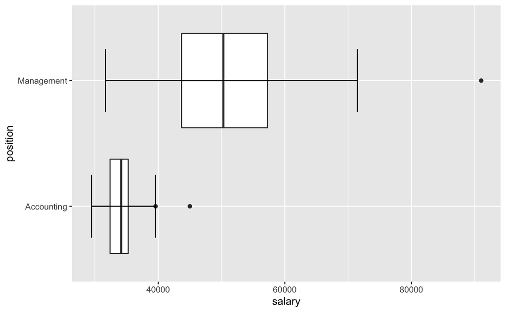

```r
jobs %>%
  ggplot(aes(x = salary,
             y = position)) +
  geom_boxplot() +
  stat_boxplot(geom = "errorbar", width = 0.5)
```

Task - 10 mins Investigate and comment on the centrality and spreads of `distribution_1` and `distribution_2` produced by the following function calls. Use `geom_boxplot()` and `skim()` first Next, plot histograms to confirm your descriptions. [Don’t worry about what the functions generating distribution_1 and distribution_2 are doing]

| y |
| --- |
| 18.7095845 |
| -0.6469817 |
| 8.6312841 |
| 11.3286260 |
| 9.0426832 |
| 3.9387548 |
| 20.1152200 |
| 4.0534096 |
| 25.1842371 |
| 4.3728590 |

[output cut: 290 more lines]

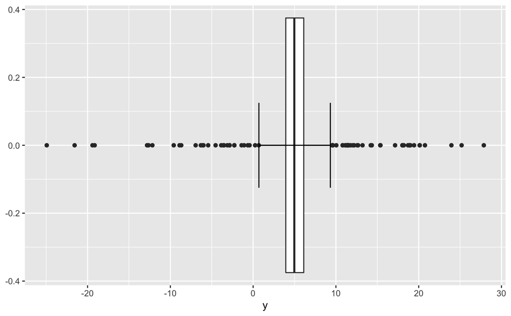

```r
distribution_1 %>%
  ggplot(aes(x = y)) +
  geom_boxplot() +
  stat_boxplot(geom = "errorbar", width = 0.25)
```

```r
distribution_1 %>%
  skim()
```

```
── Data Summary ────────────────────────
                           Values
Name                       Piped data
Number of rows             300
Number of columns          1
_______________________
Column type frequency:
  numeric                  1
________________________
Group variables            None
```

|  | skim_variable | n_missing | complete_rate | mean | sd | p0 | p25 | p50 | p75 | p100 | hist |
| --- | --- | --- | --- | --- | --- | --- | --- | --- | --- | --- | --- |
| 1 | y | 0 | 1 | 5.075765 | 6.045745 | -24.9309 | 3.945366 | 4.976071 | 6.115762 | 27.86645 | ▁▁▇▂▁ |

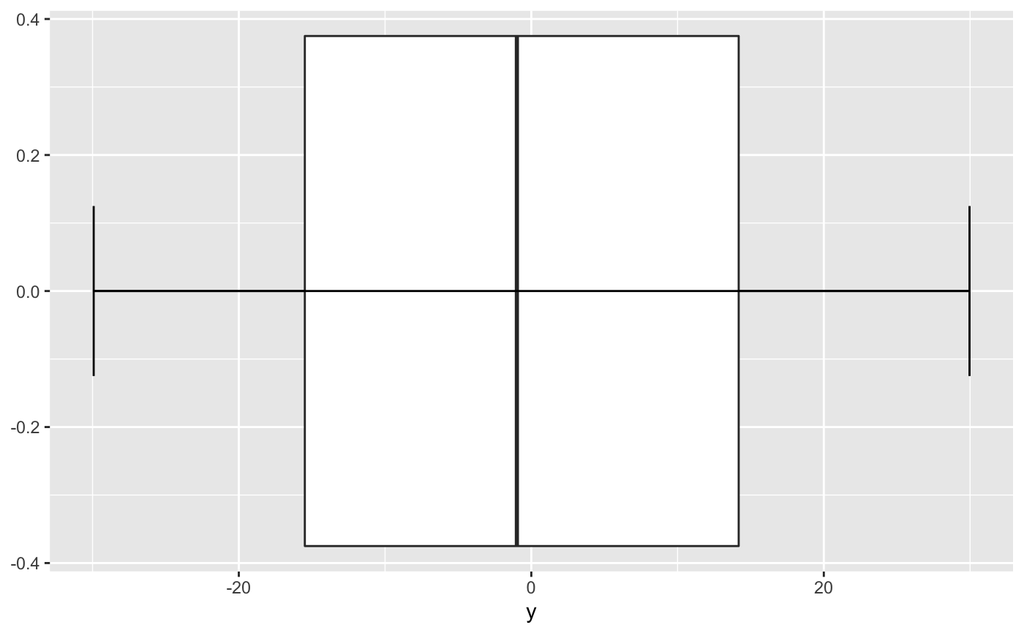

```r
distribution_2 %>%
  ggplot(aes(x = y)) +
  geom_boxplot()  +
  stat_boxplot(geom = "errorbar", width = 0.25)
```

```r
distribution_2 %>%
  skim()
```

```
── Data Summary ────────────────────────
                           Values
Name                       Piped data
Number of rows             1000
Number of columns          1
_______________________
Column type frequency:
  numeric                  1
________________________
Group variables            None
```

|  | skim_variable | n_missing | complete_rate | mean | sd | p0 | p25 | p50 | p75 | p100 | hist |
| --- | --- | --- | --- | --- | --- | --- | --- | --- | --- | --- | --- |
| 1 | y | 0 | 1 | -0.7187298 | 17.32224 | -29.92365 | -15.48538 | -0.9870809 | 14.17994 | 29.96274 | ▇▇▇▇▇ |

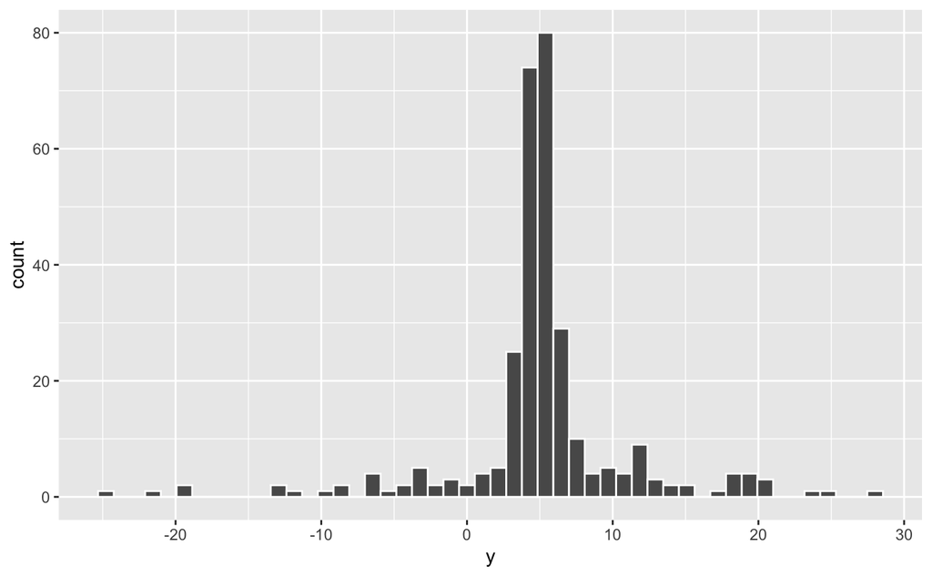

```r
distribution_1 %>%
  ggplot(aes(x = y)) +
  geom_histogram(col = "white", bins = 50)
```

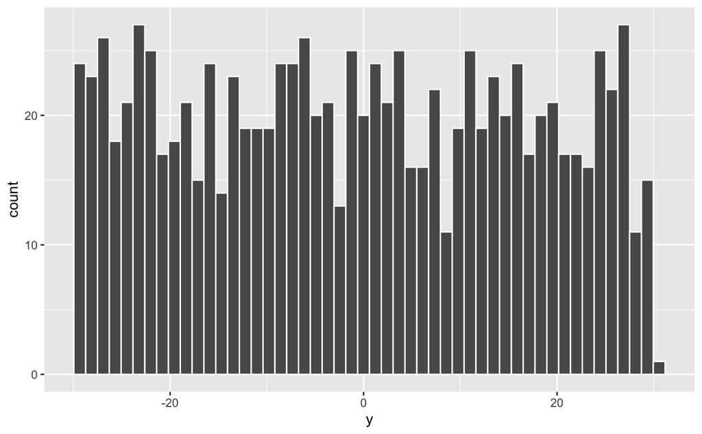

```r
distribution_2 %>%
  ggplot(aes(x = y)) +
  geom_histogram(col = "white", bins = 50)
```

```r
library(e1071)
```

```r
distribution_2 %>%
  summarise(skew = skewness(y, type = 1))
```

| skew |
| --- |
| 0.02866984 |

highly symmetric distribution

| ...1 | x |
| --- | --- |
| 1 | 0.025782923 |
| 2 | 0.096937638 |
| 3 | 0.028380935 |
| 4 | 0.092154008 |
| 5 | 0.064928831 |
| 6 | 0.028373998 |
| 7 | 0.060405447 |
| 8 | 0.024016013 |
| 9 | 0.042966035 |
| 10 | 0.085015384 |

[output cut: 990 more lines]

```r
right_skewed %>%
  summarise(skew = skewness(x, type = 1))
```

| skew |
| --- |
| 1.408127 |

highly right skewed

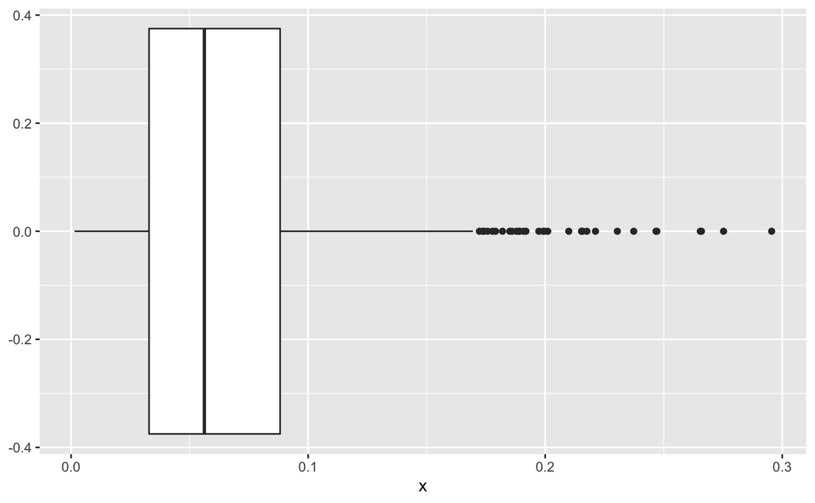

```r
right_skewed %>%
  ggplot(aes(x = x)) +
  geom_boxplot()
```

> 1. Long tail of outliers to the right of the box
> 2. Q2 (median) is closer to Q1 than to Q3
> 3. Left whisker is shorter than right whisker

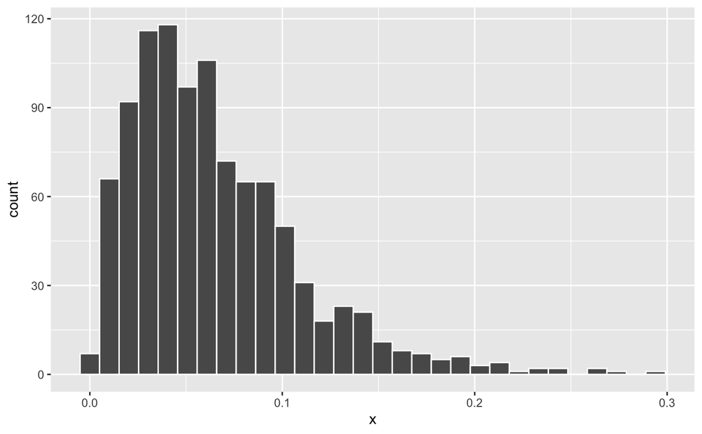

```r
right_skewed %>%
  ggplot(aes(x = x)) +
  geom_histogram(col = "white")
```

```r
right_skewed %>%
  skim()
```

```
── Data Summary ────────────────────────
                           Values
Name                       Piped data
Number of rows             1000
Number of columns          2
_______________________
Column type frequency:
  numeric                  2
________________________
Group variables            None
```

|  | skim_variable | n_missing | complete_rate | mean | sd | p0 | p25 | p50 | p75 | p100 | hist |
| --- | --- | --- | --- | --- | --- | --- | --- | --- | --- | --- | --- |
| 1 | ...1 | 0 | 1 | 500.50000000 | 288.81943610 | 1.000000000 | 250.75000000 | 500.50000000 | 750.25000000 | 1000.0000000 | ▇▇▇▇▇ |
| 2 | x | 0 | 1 | 0.06516195 | 0.04455074 | 0.001483156 | 0.03290218 | 0.05624313 | 0.08819214 | 0.2955159 | ▇▅▁▁▁ |

## Variance

> a single number value for a measure of spread a measure of how far each value in the data set is from the mean

[3, 6, 4, 20, 4]

```r
num_set <- c(3, 6, 4, 20, 4)

mean(num_set)
```

```
[1] 7.4
```

> sum of the differences from the mean squared and then divided by the total number of elements - 1 mean difference from the mean

A hypothetical example

- a survey people about their weight
- marathon runners
- commuters
- the mean weights are the same

sampled 50 from each group

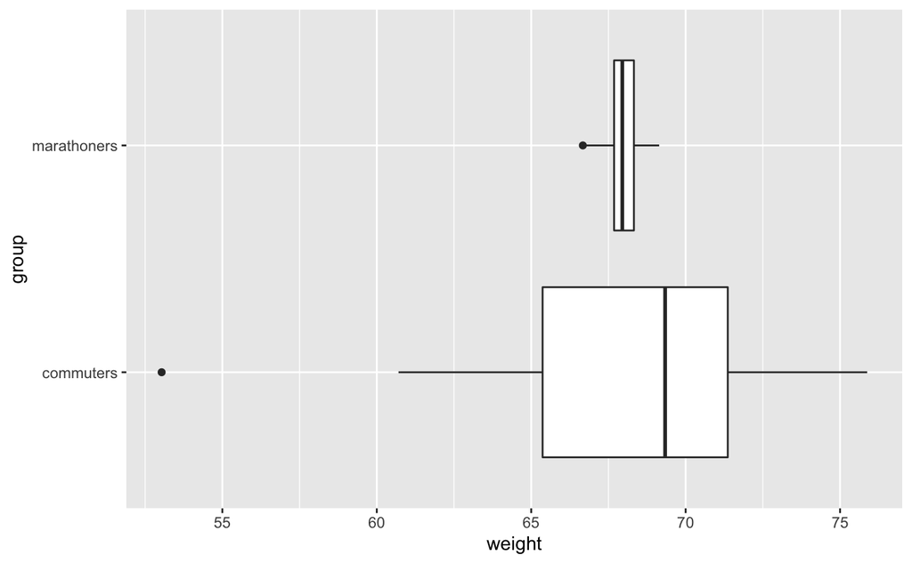

```r
set.seed(42)

londoner_weights <- tibble(
  marathoners = rnorm(50, mean = 68, sd = 0.5),
  commuters = rnorm(50, mean = 68, sd = 5)
) %>%
  pivot_longer(cols = everything(), names_to = "group", values_to = "weight")

ggplot(londoner_weights) +
  aes(x = weight, y = group) +
  geom_boxplot()
```

```r
londoner_weights %>%
  group_by(group) %>%
  summarise(
    mean_weight = mean(weight),
    var_weight = var(weight),
    st_dev_weight = sd(weight),
    st_dev_long = sqrt(var_weight)
  )
```

| group | mean_weight | var_weight | st_dev_weight | st_dev_long |
| --- | --- | --- | --- | --- |
| commuters | 68.50351 | 21.3898332 | 4.6249144 | 4.6249144 |
| marathoners | 67.98216 | 0.3314745 | 0.5757382 | 0.5757382 |

weight = kg variance = kg^2 std dev = sqrt(varriance) std dev = kg

the average deviance from the mean weight of commuters (68.5kg) was 4.6kg

# Calculating variance longhand

$$s^2 = \frac{1}{n-1}\sum{(x - \bar{x})^2}$$
To calculate variance: > get the difference between each value and the mean > square each value > add up these squared values > divide by number of total values - 1

To calculate the standard deviation: > sqrt the variance

Task: Calculate the variance and standard deviation for the salaries in accounting & management

```r
jobs %>%
  group_by(position) %>%
  summarise(var_salary = var(salary),
            st_dev_salary = sd(salary))
```

| position | var_salary | st_dev_salary |
| --- | --- | --- |
| Accounting | 5681909 | 2383.676 |
| Management | 119695746 | 10940.555 |

```r
NA
```

- The standard deviation of management is > 4x more than that of accounting
- Values of management salaries are much more spread